# Stat 226 - Lecture 3

09/03/13

### Announcements

- Official office hours schedule now posted on Blackboard.
- Any initial questions?

### Outline for Data Analysis

- Start by analyzing each variable individually! After exam 2, we'll cover relationships between variables.
- In short, we want to know the **distribution** of each variable.
- We can fully specify a **distribution** with a **frequency table**.
  - Most graphics in Chapters 3&4 are visual representations of a **frequency table**.
  - Except for boxplots, which is a visual representation of **percentiles**.
- We can summarize a **distribution** with other **numerical summaries**.
  - For example, a mean is a numerical summary.
  - Choosing appropriate numerical summaries depends on the type (categorical/quantitative) and the shape of the distribution.

### Every pitch by Mariano Rivera in '11

```
        description type start_speed month
1     Called Strike   FC        91.3    04
2   In play, out(s)   FF        91.5    04
3     Called Strike   FC        91.8    04
4     Called Strike   FC        91.8    04
5              Foul   FC        92.0    04
6              Foul   FC        92.0    04
7              Ball   FC        89.5    04
8              Ball   FC        89.5    04
9              Foul   FC        91.0    04
10             Foul   FC        91.0    04
11             Ball   FC        90.5    04
12             Ball   FC        90.5    04
13  In play, out(s)   FC        90.8    04
14  In play, out(s)   FC        90.8    04
```

[output cut: 86 more lines]

```r
toy$description <- factor(toy$description)
toy$type <- factor(toy$type)
toy$month <- factor(toy$month)
toy$start_speed <- as.numeric(toy$start_speed)
```

### Pitch Description

- What type of variable is the pitch **description**?
- **description** is a **nominal** variable. Here is it's distribution (shown as a **frequency table**):

```
          description
 Ball           :98
 Foul           :71
 Called Strike  :67
 In play, out(s):39
 Swinging Strike:23
 In play, no out:11
 (Other)        : 6
```

### Relative Frequencies

- Now, here is the **relative frequency**:

```
                      [,1]
  Ball                0.311
  Called Strike       0.213
  Foul                0.225
  Foul (Runner Going) 0.003
  Foul Tip            0.006
  In play, no out     0.035
  In play, out(s)     0.124
  In play, run(s)     0.010
  Swinging Strike     0.073
```

- There were 315 pitches, so divide every number in the frequency table by this number to get the relative frequencies.

### Bar Chart

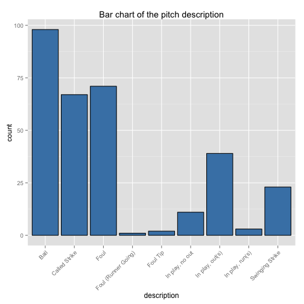

### Pareto Chart

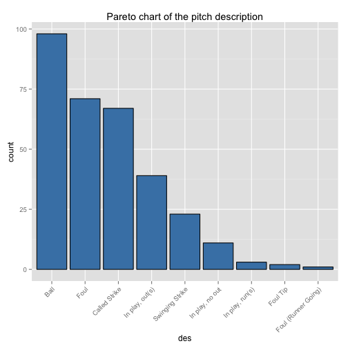

- Pareto charts always place the **mode** as the left-most category.

### Pie Chart

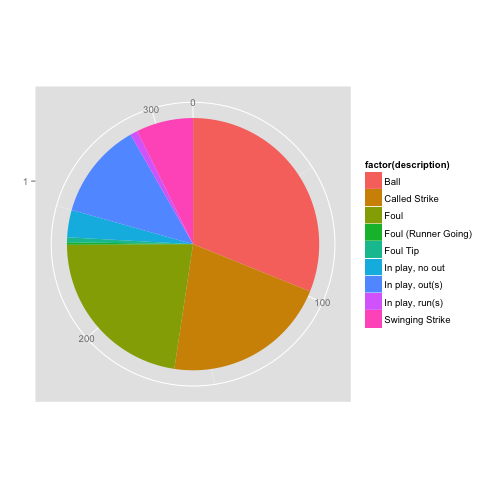

### Month

```
 month
 04:81
 05:29
 06:13
 07:52
 08:60
 09:79
 10: 1
```

### Bar Chart

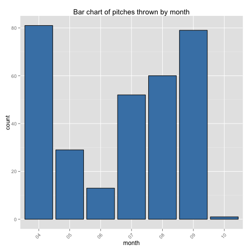

### Remark

- Would a pareto chart work for the **month** variable?
  - You probably shouldn't change the ordering of time!
- When in doubt, use a bar chart to visualize the **distribution** of a categorical variable.
- If the variable is **nominal**, pareto charts are preferred!
- If the variable is **ordinal**, be careful! You may not want to change the ordering of the categories!

### Pitch speed

- **start_speed:** The speed of the pitch as it left the hand. This is **quantitative**.
- To visualize the distribution a single quantitative variable, use a histogram.
- Since quantitative variables don't have “categories”, we have to create them!
- Although histograms look similar to bar charts, histograms are harder to make.

### Choosing binwidths

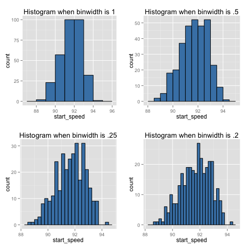

- Notice that all the 'binwidths' (within each plot) are equal!
- Which do you think looks best?

### Frequencies when binwidth is 1

```
          [,1]
  [88,89)    2
  [89,90)   23
  [90,91)   57
  [91,92)  100
  [92,93)  100
  [93,94)   32
  [94,95)    1
```

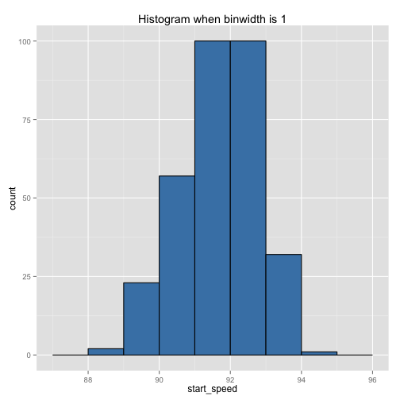

### Visual representation

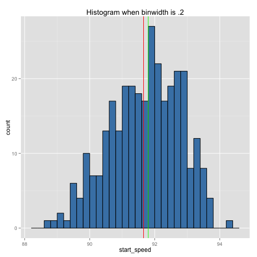

### Boxplot vs Histogram

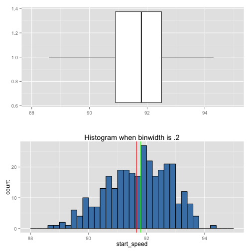

- A **boxplot** is another visual representation of a distribution, but instead of a **frequency table**, it uses the **5 number summary**.
- All of these numbers can be thought of as **percentiles**.
- The **median** is also known as the 50th percentile.
- What percentile is the minimum? Maximum?
- **Q1** is the median of the first half of the distribution.